# Lab 8, Team All Stars

Johnny Tamanaha, Emily Archambault, Eugene Miller, Kaiyuan Fan, Jingzhi Zhang

## Prep for Lab 9

Domain Expert: Sven Johannson (Economist at Stockholm School of Economics)

Team Question: What factors appear to have the greatest influence on the Happiness Score of a country? This question is important because understanding the reasons behind what makes the people in some countries happier than others is the key to improving overall happiness for everyone. Finding what the common links are can guide how policies are developed, can shape our understanding of cultures around the world, and can give better insight into the biggest problems facing people today.

Dataset Description: The United Nations World Happiness Report is a survey of the state of global happiness. The 2017 report ranks 155 countries by their happiness levels using the happiness scores and rankings use data from the Gallup World Poll. This report estimates the extend to which six variables contribute to happiness score: GDP per Capita, Family, Life Expectancy, Freedom, Generosity, Trust, Government Corruption. Adding these columns up gives happiness score.

# Emily Archambault

How does the extent to which the perception of corruption/trust in government’s contribution to the overall happiness score vary by region of the world? How does the extent to which family’s contribution to the overall happiness score vary by region of the world?

These questions are interesting because the answers could give a sense as to what factors are most important in people’s lives, and how those factors could depend on where they live. It could give insight into how different countries are run, and provide lessons, either positive or negative, for the rest of the world.

# Eugene Miller

How does happiness score vary by region of the world? Do the happiest countries have a low or high variance of individual scores for family, corruption, gdp per capita etc?

These questions are important because they give us insight into why happy countries are happy in historical context, and to whether a high amount of one factor leads to happiness or whether a low variability between scores leads to a high amount of happiness. Is it better for a country to be strong in one specific asepct or be more well rounded when it comes to quality of life?

# Johnny Tamanaha

How does freedom affect happiness in each continent? How does freedom affect happiness in each region?

These questions are interesting because freedom is such a defining characteristic or regions and countries. This could show evidence for an optimal level of freedom to maximize happiness for citizens.

# Jingzhi Zhang

How does The extent to which generosity contributed to the calculation of the happiness score vary by the region of the world? How does the extent to which life expectancy contributed to the calculation of the happiness score vary by the region of the world?

These questions are interesting because the answer could show that how do generosity and life expectancy in different countries influence people’s happiness. This could give insight into how how to improve the national policy to improve the national happiness index.

# Kaiyuan Fan

How does Dystopia Residual contribute to the calculation of happiness score for the different countries?

What is the relationship between healthy and economy for different counties.

These questions are interesting because we can viually see how Dystopia Residual influence the citzens’ happiness. Economy might influence the medical condition usually, which may influence the happiness and healthy of the citzens. We can check this by the questions.

# Tanganyika Data

```
## # A tibble: 816 x 3
##    year1 measurement   value
##    <dbl> <chr>         <dbl>
##  1  1996 BSi         -1.26
##  2  1986 BSi         -1.34
##  3  1976 BSi         -1.37
##  4  1966 BSi         -1.41
##  5  1956 BSi         -1.39
##  6  1946 BSi         -1.45
##  7  1937 BSi         -1.35
##  8  1927 BSi         -1.11
##  9  1918 BSi         -0.886
## 10  1908 BSi         -0.0602
## # ... with 806 more rows
```

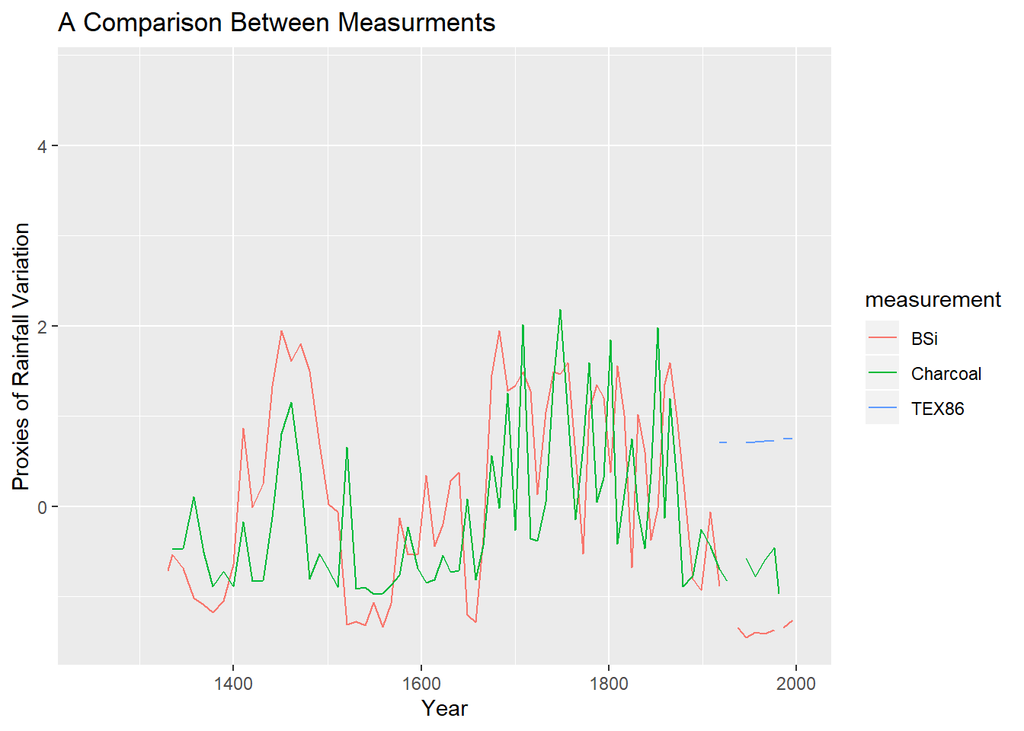

# Biogenic Silica in Malawi Visualization

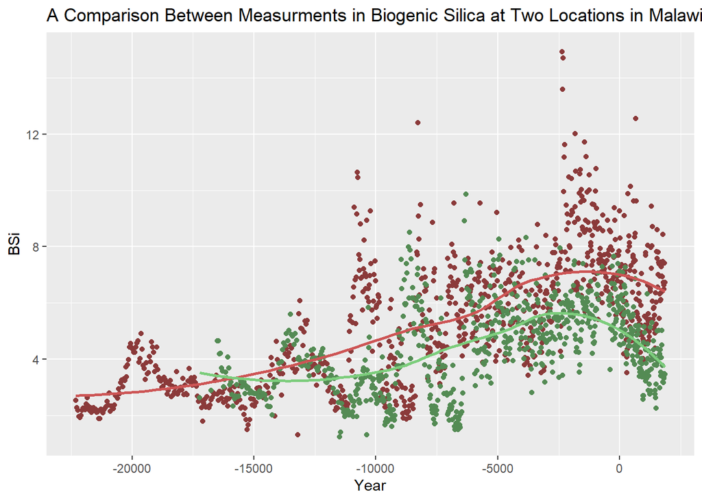

# VOI Rainfall Visualization

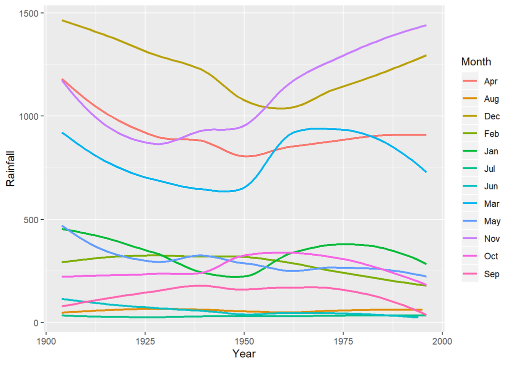

# CRU and MAM Rainfall Data

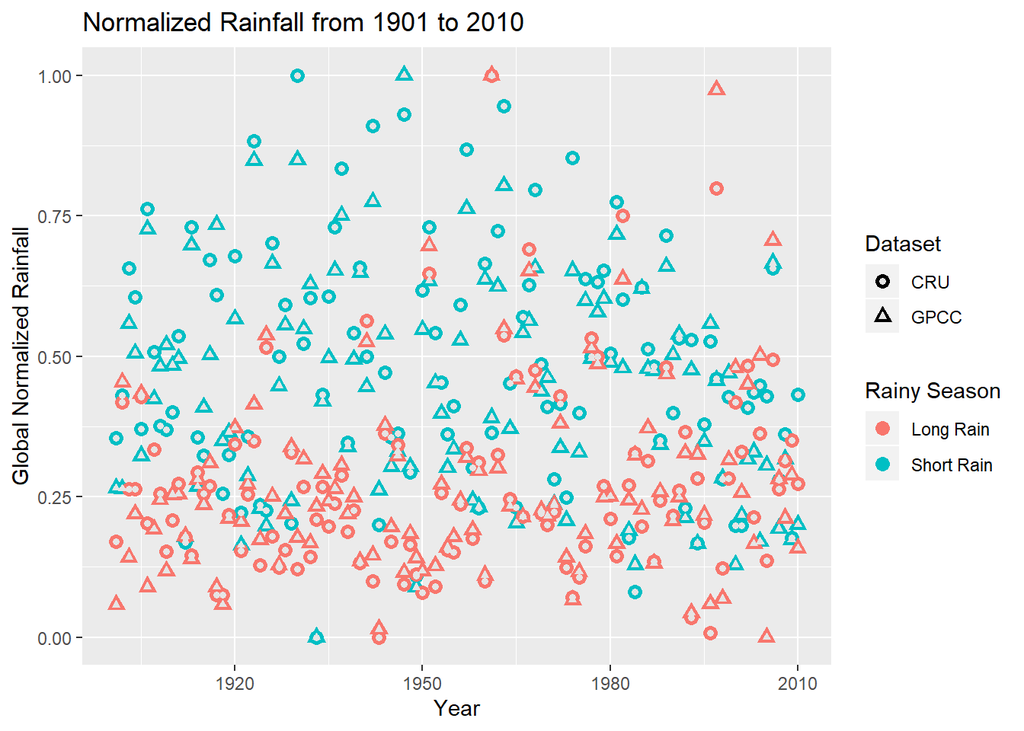

# Challa Data

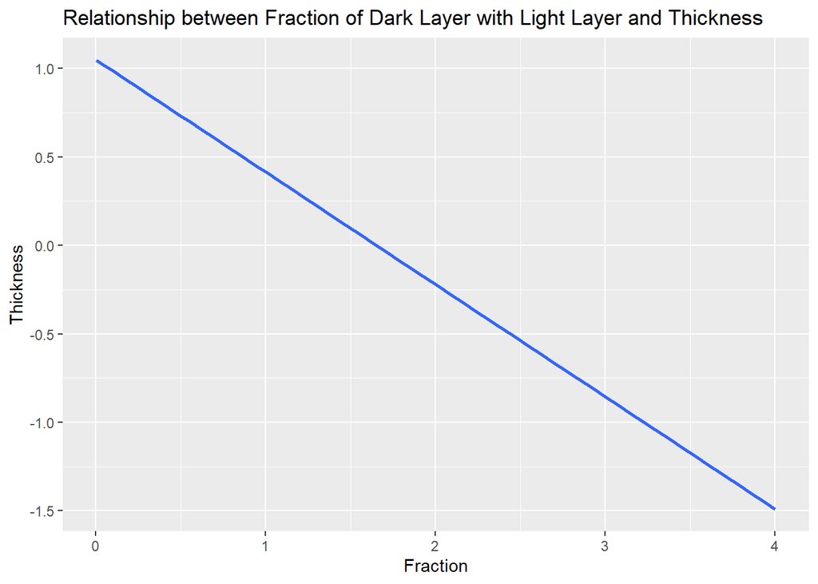